# The Economics of Happiness - Fall2022 STAT447 Project Report

Mingyu Sun(mingyus2)

Yuxuan Fei (yfei7)

Yuanqin Zhou (yuanqin2)

## Introduction

Based on the World Happiness Report https://www.kaggle.com/datasets/unsdsn/world-happiness data, we are more interested in the economics factors and the prediction of the happiness score. Therefore, the data set we plan to use is a much larger data set with more economics and finance variables.

## Data Wrangling

### Library

Load R Packages for the future operations.

```r
library(dplyr)
library(zoo)
```

### Load Data

The original dataset contains 3 csv files, which can be retrieved from https://www.kaggle.com/datasets/nikbearbrown/the-economics-of-happiness-teh.

The 3 csv files are: **TEH_Base_ISO_3166_country_codes_base.csv** which contains the names and corresponding codes of the countries, **TEH_World_Happiness_2015_2019.csv** which contains the happiness scores and basic economics indexes of the countries, **The_Economics_of_Happiness_TEH_11222022.csv** which contains more economics information of the countries. As we are focusing on the happiness score and its economics factors, the name and codes of the countries will not be used. Therefore, we only load 2 csv files:**TEH_World_Happiness_2015_2019.csv** and **The_Economics_of_Happiness_TEH_11222022.csv**.

```r
data1 = read.csv('TEH_World_Happiness_2015_2019.csv')
data2 = read.csv('The_Economics_of_Happiness_TEH_11222022.csv')
```

There are 782 observation and 10 variables in **TEH_World_Happiness_2015_2019.csv**.

```r
dim(data1)
```

```
## [1] 782  10
```

```r
dim(data2)
```

```
## [1] 1503   34
```

### Data Merging

The dependent variable of our model is in data1, while all the variables of the model features we intend to use are in data2. So in this step, we will match ‘Happiness Score’ based on ‘country’ and ‘year’ and merge these two data sets by ‘dplyr’.

To make joins work properly, first create a composite key

```r
#data1 already had the names we want
data1["key"] = paste0(data1$Country,data1$Year)
data2["key"] = paste0(data2$Country.Name,data2$Time)
```

```r
summary(data1$Year)
```

```
##    Min. 1st Qu.  Median    Mean 3rd Qu.    Max.
##    2015    2016    2017    2017    2018    2019
```

```r
summary(data2$Time)
```

```
##    Min. 1st Qu.  Median    Mean 3rd Qu.    Max.    NA's
##    2015    2016    2018    2018    2020    2021       5
```

According to the observation, data2 has data for 2015-2021, while data1 has only 2015-2019. If we use leftjoin(taking the whole data2), there is a chance that we can manually fill the data for 2020-2021 according to the data for that country for 2015-2019 (NA value for happiness score). But if we use rightjoin (taking the whole data1), the NA value for happiness score can only be deleted because there is no corresponding country in data2 and it is difficult to fill it by speculation.

```r
df= left_join(data2,data1[,c("Happiness.Score","key")],by="key")
```

### Data Cleaning

We make a reasonable assumption that the happiness scores of countries do not change too much over time. Based on this assumption, the first thing we want to do is to calculate the happiness scores according to country groupings, which will help us fill in the missing data for 2020-2021.

Before we do that, let’s take a look at the target data type to avoid us using strings for our calculations.

```r
class(df$Happiness.Score)
```

```
## [1] "numeric"
```

Continue

```r
df = df %>%
  group_by(Country.Name) %>%
  mutate(Country.Ave = mean(Happiness.Score,na.rm = T))
dim(df)
```

```
## [1] 1503   37
```

In fact the na.rm parameter in this mean function is very important. It helps us filter out the countries we want. If a country has data from 2015-2019, the Country.Ave we get will be a number; if a country doesn’t have any data from 2015-2019, the Country.Ave we get will be a NA. This helps us easily find the data we don’t have a way to fill.

Remove the NAs for ‘Country.Ave’

```r
df = df[!is.na(df$Country.Ave),]
dim(df)
```

```
## [1] 994  37
```

Filling

```r
df = df %>%
  group_by(Country.Name) %>%
  mutate(Happiness.Score= ifelse(is.na(Happiness.Score), mean(Happiness.Score, na.rm=TRUE), Happiness.Score)) %>%
  ungroup(Country.Name)
dim(df)
```

```
## [1] 994  37
```

```r
df = na.omit(df)
dim(df)
```

```
## [1] 994  37
```

Just to make sure we filled in the numbers. Also we have noticed the unusual missing values in this dataset. They are ‘..’ instead of NA.

So the next step is to deal with these “missing values”.

Still following the previous assumptions, we decided to fill in these blanks according to the country division. Since most of the variables can be considered as highly correlated with the country like unemployment rate and GDP, etc.

Before we can do that we need to put all the “..” into an ‘impossible’ number, then turn the whole column into a column with the number type, and finally turn that ‘impossible’ number into NA

```r
df = df %>% mutate_all(~replace(., . == "..", 0.123456789))
```

Convert

```r
x = names(df)[5:34] #obtain col names
df = df %>% mutate_at(vars(x), as.numeric)
```

Go back to NA

```r
df = df %>% mutate_all(~replace(., . == 0.123456789, NA))
```

To be able to process multiple columns at once with dplyr, we need to create a function first

```r
convert_na <- function(a) {
  return (ifelse(is.na(a), mean(a, na.rm=TRUE), a))
}
```

Use across function in dplyr!

```r
df = df %>%
  group_by(Country.Name) %>%
  mutate(across(x,convert_na)) %>%
  ungroup(Country.Name)
dim(df)
```

```
## [1] 994  37
```

After filling in, we find that there are still many feature variables with values of NaN.We discard columns with the number of NA values greater than 150 because they are of little analytical value.

```r
df = df[,sapply(X = df, FUN = function(x) sum(is.na(x))) < 150]
```

We decided to continue interpolation and take the whole column average by na.aggregate function

```r
df[,5:24] = na.aggregate(df[,5:24])
```

In the last step, check if there are any missing na values

```r
df = na.omit(df)
```

## Exploratory Data Analysis

After data wrangling, we will first get insight into the data. There are 994 observations and 27 variables. The variables are as following:

```r
colnames(df)
```

```
##  [1] "Country.Name"
##  [2] "Country.Code"
##  [3] "Time"
##  [4] "Time.Code"
##  [5] "CO2.emissions..kg.per.PPP...of.GDP...EN.ATM.CO2E.PP.GD."
##  [6] "General.government.final.consumption.expenditure....of.GDP...NE.CON.GOVT.ZS."
##  [7] "School.enrollment..tertiary....gross...SE.TER.ENRR."
##  [8] "Unemployment..total....of.total.labor.force...national.estimate...SL.UEM.TOTL.NE.ZS."
##  [9] "Unemployment..youth.total....of.total.labor.force.ages.15.24...national.estimate...SL.UEM.1524.NE.ZS."
## [10] "Gross.capital.formation....of.GDP...NE.GDI.TOTL.ZS."
## [11] "Gross.domestic.savings....of.GDP...NY.GDS.TOTL.ZS."
## [12] "Government.expenditure.on.education..total....of.GDP...SE.XPD.TOTL.GD.ZS."
## [13] "Life.expectancy.at.birth..total..years...SP.DYN.LE00.IN."
## [14] "Age.dependency.ratio..young....of.working.age.population...SP.POP.DPND.YG."
## [15] "GDP.per.capita..PPP..constant.2017.international.....NY.GDP.PCAP.PP.KD."
## [16] "GDP.per.capita..constant.2015.US....NY.GDP.PCAP.KD."
## [17] "Foreign.direct.investment..net.inflows....of.GDP...BX.KLT.DINV.WD.GD.ZS."
## [18] "GDP.per.capita.growth..annual.....NY.GDP.PCAP.KD.ZG."
## [19] "Trade....of.GDP...NE.TRD.GNFS.ZS."
## [20] "Inflation..consumer.prices..annual.....FP.CPI.TOTL.ZG."
## [21] "Net.migration..SM.POP.NETM."
## [22] "Strength.of.legal.rights.index..0.weak.to.12.strong...IC.LGL.CRED.XQ."
## [23] "Mortality.rate..under.5..per.1.000.live.births...SH.DYN.MORT."
## [24] "Population.growth..annual.....SP.POP.GROW."
## [25] "key"
## [26] "Happiness.Score"
## [27] "Country.Ave"
```

Exploratory data analysis helps helps to find fundamental relationship between the happiness score (response variable) and other variables (independent variables).

### Library

```r
library(ggplot2)
library(dplyr)
```

### Happiness Score & Countries

It is reasonable that happiness score varies with different countries. Given a specific country, we calculated the average of happiness score from 2015 to 2021.

```r
sub_df = group_by(df, Country.Name) |>
          summarize(avg.happiness = mean(Happiness.Score)) |>
          arrange(desc(avg.happiness))
```

The overview of the happiness score.

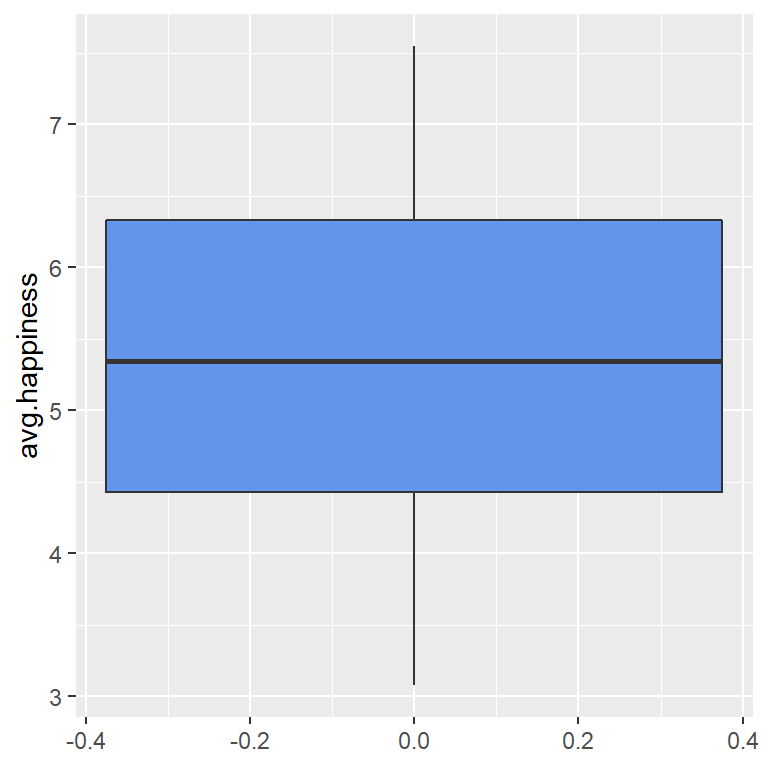

```r
ggplot(sub_df, aes(y=avg.happiness))+
  geom_boxplot(fill="#6495ED")
```

As the plot shows above, the lowest happiness score is around 3. The highest happiness score is around 7.5. The median is around 5.5, the 0.25 quantile is around 4.5 the 0.75 quantile is 6. Therefore, we can conclude that the happiness score of most of the countries is around 4.5 to 6.

Then we select top 20 countries lowest 20 countries and as the following plots

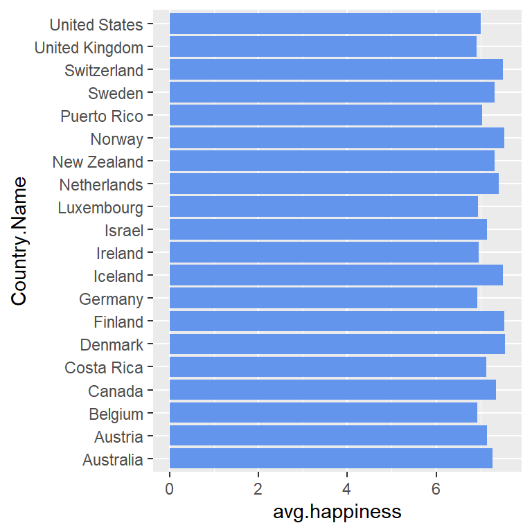

```r
sub_df_top = sub_df[1:20, ]
sub_df_low = sub_df[(nrow(sub_df)-19):nrow(sub_df), ]
ggplot(sub_df_top, aes(y=avg.happiness, x=Country.Name)) +
  geom_bar(position="dodge", stat="identity", fill = "#6495ED") +
  coord_flip()
```

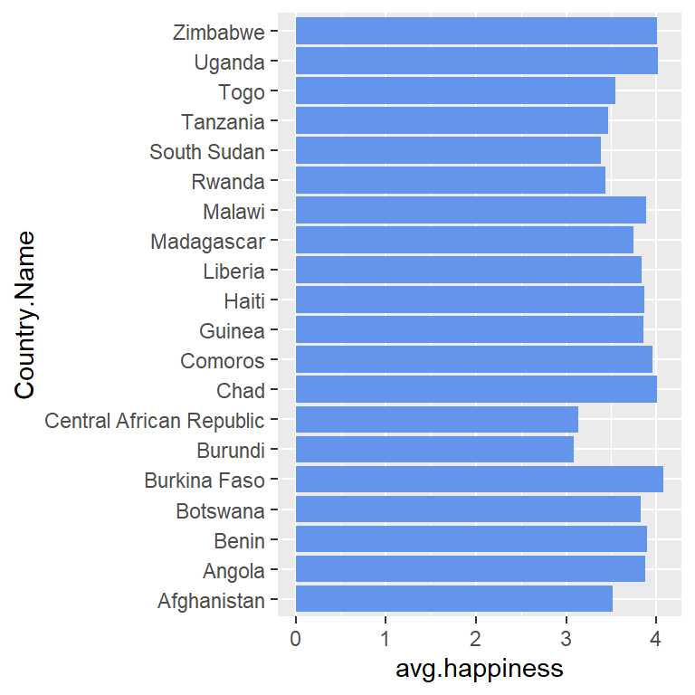

```r
ggplot(sub_df_low, aes(y=avg.happiness, x=Country.Name)) +
  geom_bar(position="dodge", stat="identity", fill = "#6495ED") +
  coord_flip()
```

As the plots show above, the highest happiness score is around 7 but the lowest happniess score is around 3 and 4. Among them, Denmark, Norway and Finland have the higest happiness score and Central African Republic, Burundi and South Sudan have the lowest happiness score. Therefore, we can conclude that the happiness score is relavant to countries.

### Happniess Score & Time

Anonther important factor affecting the happiness score is the time. In order to see the trend of the happiness score with the time. We again calculate the average of happiness score among all the countries.

```r
sub_df = group_by(df, Time) |>
          summarize(avg.happiness = mean(Happiness.Score))
```

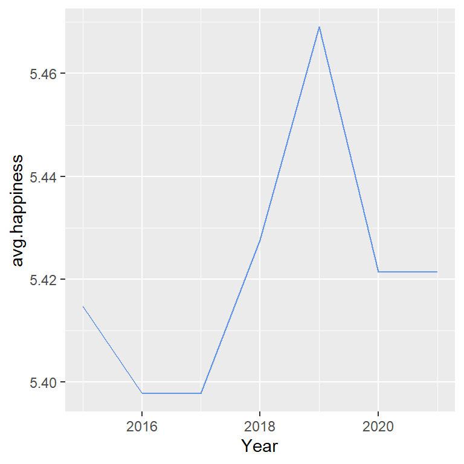

```r
ggplot(data = sub_df, mapping = aes(x = Time, y = avg.happiness)) + geom_line(color = "#6495ED") + xlab('Year')
```

From this plot, we can see that the world happiness score reach its highest value in 2019 and the reach its lowest value in 2016 to 2017. Therefore, we can see that the time is also affecting the world happiness score.

### Other Economics Factors

As we know the world happiness score is mainly affected by the countries and the time. To further analyze, the reason behind is that the economics varies from the countries and the time. Therefore, we will focus on the economics factors from the countries and the time, for example unemployment.

Again, we would like to find the relationship between countries and Unemployment. Given a particular country, we calculate the average Unemployment and select top 20 and lowest 20.

```r
sub_df = group_by(df, Country.Name) |>
          summarize(avg.unemp = mean(Unemployment..total....of.total.labor.force...national.estimate...SL.UEM.TOTL.NE.ZS.)) |>
          arrange(desc(avg.unemp))
sub_df_top = sub_df[1:20, ]
sub_df_low = sub_df[(nrow(sub_df)-19):nrow(sub_df), ]
```

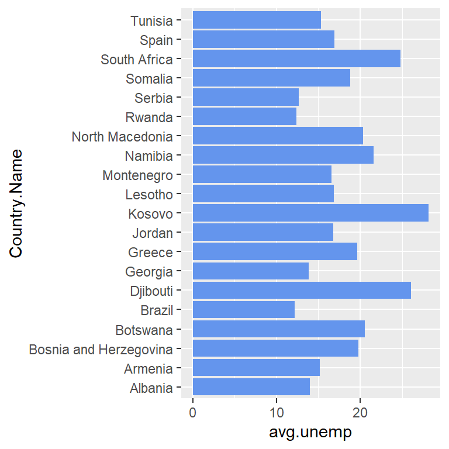

```r
ggplot(sub_df_top, aes(y=avg.unemp, x=Country.Name)) +
  geom_bar(position="dodge", stat="identity", fill = "#6495ED") +
  coord_flip()
```

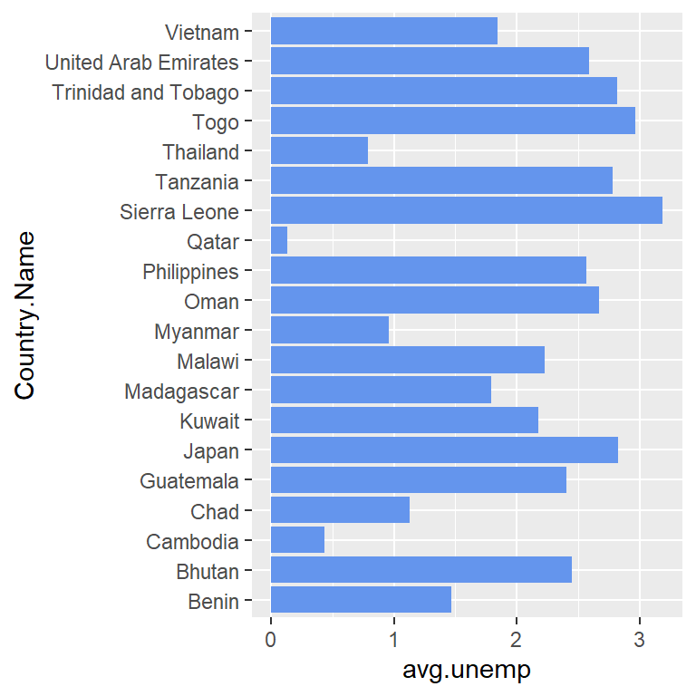

```r
ggplot(sub_df_low, aes(y=avg.unemp, x=Country.Name)) +
  geom_bar(position="dodge", stat="identity", fill = "#6495ED") +
  coord_flip()
```

From these two plots, we can see that highest and lowest unemployment countries are different from the highest and lowest happiness score countries.

We would like to further the time trend of unemployment.

```r
sub_df = group_by(df, Time) |>
          summarize(avg.unemp = mean(Unemployment..total....of.total.labor.force...national.estimate...SL.UEM.TOTL.NE.ZS.))
```

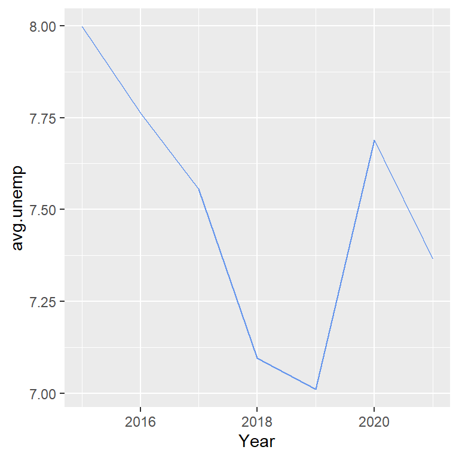

```r
ggplot(data = sub_df, mapping = aes(x = Time, y = avg.unemp)) + geom_line(color = "#6495ED") + xlab('Year')
```

From this plot, we can see that unemployment decreases from 2015 to 2019 and increases in 2020. It reaches the highest value in 2015 and reaches the lowest in 2019. The world happiness score reaches it highest value also in 2019. Therefore, the relationship between happiness score and unemployment requires further research.

## Models

Remove the following columns: country_name, country_code, time, time_code, country_ave, key.

```r
head(df)
```

```
## # A tibble: 6 × 27
##   Countr…¹ Count…²  Time Time.…³ CO2.e…⁴ Gener…⁵ Schoo…⁶ Unemp…⁷ Unemp…⁸ Gross…⁹
##   <chr>    <chr>   <dbl> <chr>     <dbl>   <dbl>   <dbl>   <dbl>   <dbl>   <dbl>
## 1 Afghani… AFG      2015 YR2015   0.0828    16.3   10.1     9.49    14.2    24.2
## 2 Afghani… AFG      2016 YR2016   0.0756    16.3   10.1     9.49    14.2    24.2
## 3 Afghani… AFG      2017 YR2017   0.0640    16.3   10.1    11.2     17.6    24.2
## 4 Afghani… AFG      2018 YR2018   0.0784    16.3    9.69    9.49    14.2    24.2
## 5 Afghani… AFG      2019 YR2019   0.0743    16.3   10.1     9.49    14.2    24.2
## 6 Afghani… AFG      2020 YR2020   0.0750    16.3   10.6    11.7     16.2    24.2
## # … with 17 more variables:
## #   Gross.domestic.savings....of.GDP...NY.GDS.TOTL.ZS. <dbl>,
## #   Government.expenditure.on.education..total....of.GDP...SE.XPD.TOTL.GD.ZS. <dbl>,
## #   Life.expectancy.at.birth..total..years...SP.DYN.LE00.IN. <dbl>,
## #   Age.dependency.ratio..young....of.working.age.population...SP.POP.DPND.YG. <dbl>,
## #   GDP.per.capita..PPP..constant.2017.international.....NY.GDP.PCAP.PP.KD. <dbl>,
## #   GDP.per.capita..constant.2015.US....NY.GDP.PCAP.KD. <dbl>, …
```

```r
df2 <- select(df, -c(Country.Ave, key))
df2 <- select(df2, -c(1:4))
colnames_new<-c("co2","gov_consumption","school_enrollment","unemployment_total", "unemployment_youth", "gross_gdp", "gross_savings", "gov_spending_education", "life_exp", "ADP", "GDPPC_2017", "GDPPC_2015", "Foreign_Investment", "GDPPC_growth", "trade_gdp", "inflation", "net_migration", "legal_rights_strength","mortality_rate", "pop_growth", "hap_score")
colnames(df2) <- colnames_new
colnames(df2)
```

```
##  [1] "co2"                    "gov_consumption"        "school_enrollment"
##  [4] "unemployment_total"     "unemployment_youth"     "gross_gdp"
##  [7] "gross_savings"          "gov_spending_education" "life_exp"
## [10] "ADP"                    "GDPPC_2017"             "GDPPC_2015"
## [13] "Foreign_Investment"     "GDPPC_growth"           "trade_gdp"
## [16] "inflation"              "net_migration"          "legal_rights_strength"
## [19] "mortality_rate"         "pop_growth"             "hap_score"
```

We first start with splitting 80% of the dataset as training data, and 20% of the dataset as testing data.

```r
library(caTools)
set.seed(1)
split <- sample.split(df2$`hap_score`, SplitRatio = 0.8)
training_set = subset(df2, split == TRUE)
test_set = subset(df2, split == FALSE)
```

### Multiple Linear Regression

```r
# Fitting Multiple Linear Regression to the Training set
ML_regression = lm(formula = `hap_score` ~ .,
               data = training_set)
summary(ML_regression)
```

```
##
## Call:
## lm(formula = hap_score ~ ., data = training_set)
##
## Residuals:
##     Min      1Q  Median      3Q     Max
## -1.4562 -0.3528  0.0101  0.3566  1.3257
##
## Coefficients:
##                          Estimate Std. Error t value Pr(>|t|)
## (Intercept)            -1.378e+00  7.902e-01  -1.743 0.081691 .
## co2                     5.904e-01  1.880e-01   3.140 0.001756 **
## gov_consumption        -2.330e-02  4.270e-03  -5.457 6.53e-08 ***
## school_enrollment       5.376e-03  1.175e-03   4.576 5.52e-06 ***
## unemployment_total     -2.456e-02  1.092e-02  -2.248 0.024853 *
## unemployment_youth     -2.354e-03  5.010e-03  -0.470 0.638632
## gross_gdp              -1.666e-03  2.876e-03  -0.579 0.562582
## gross_savings          -4.357e-03  2.135e-03  -2.041 0.041637 *
## gov_spending_education  1.756e-01  1.536e-02  11.432  < 2e-16 ***
## life_exp                8.642e-02  9.535e-03   9.064  < 2e-16 ***
## ADP                    -1.051e-02  2.838e-03  -3.703 0.000228 ***
## GDPPC_2017              6.257e-06  3.953e-06   1.583 0.113870
## GDPPC_2015              1.065e-05  3.662e-06   2.907 0.003756 **
## Foreign_Investment     -1.226e-03  1.842e-03  -0.665 0.505942
## GDPPC_growth           -9.806e-03  4.357e-03  -2.251 0.024672 *
## trade_gdp              -9.476e-04  5.013e-04  -1.890 0.059090 .
## inflation              -5.100e-04  7.307e-04  -0.698 0.485409
## net_migration           6.348e-08  3.781e-08   1.679 0.093617 .
## legal_rights_strength   7.259e-03  7.173e-03   1.012 0.311861
## mortality_rate          8.796e-03  2.130e-03   4.130 4.02e-05 ***
## pop_growth              8.311e-02  2.878e-02   2.888 0.003990 **
## ---
## Signif. codes:  0 '***' 0.001 '**' 0.01 '*' 0.05 '.' 0.1 ' ' 1
##
## Residual standard error: 0.5363 on 774 degrees of freedom
## Multiple R-squared:  0.7882, Adjusted R-squared:  0.7827
## F-statistic:   144 on 20 and 774 DF,  p-value: < 2.2e-16
```

As we can see from the result of this multi-variable linear regresion, the coefficients of most of the variables are very small, indicating that some of the predictors are correlated. Thus, a correlation analysis among the predictors is needed to identify the correlated variables and refine the dataset based on the results.

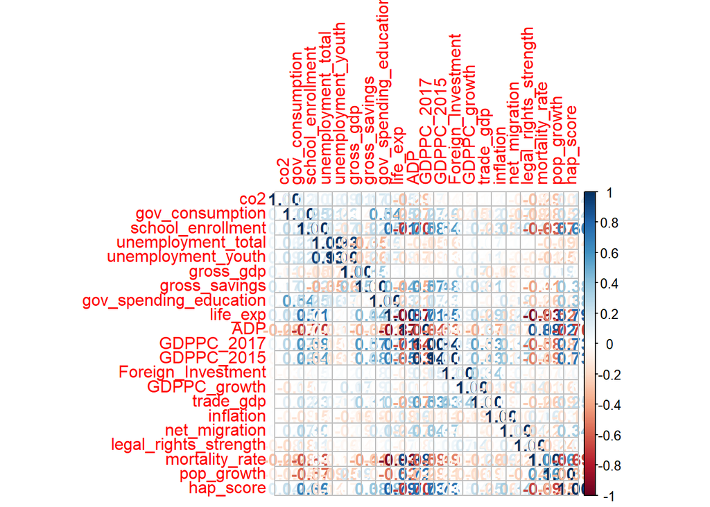

```r
########## Correlation between variables
library(corrplot)
# Finding the correlation between numerical columns
Num.cols <- sapply(df2, is.numeric)
Cor.data <- cor(df2[, Num.cols])
#corrplot(Cor.data, method = 'color')
corrplot(Cor.data, method = 'number')
```

As shown in the correlation plot, the following variables are highly correlated: (1) ‘unemployment total’ and ‘unemployment youth’ (0.93 correlation); (2) ‘GDPPC 2017’ and ‘GDPPC 2015’ (0.94 correlation); (3) ‘life exp’ and ‘mortality rate (-0.93 correlation); (4)’ ADP’ and ‘mortality rate’ (0.88 correlation); (5) ‘life exp’ and ‘ADP’ (-0.87 correlation); Repeated information is being provided by these correlated variables. Thus, we’ll remove ‘unemployment youth’, ‘GDPPC 2015’, ‘ADP’, and ‘mortality rate’.

```r
df3<-select(df2, -c('unemployment_youth','GDPPC_2015', 'mortality_rate', 'ADP'))
set.seed(1)
split <- sample.split(df3$`hap_score`, SplitRatio = 0.8)
training_set = subset(df3, split == TRUE)
test_set = subset(df3, split == FALSE)
ML_regression = lm(formula = `hap_score` ~ .,
               data = training_set)
summary(ML_regression)
```

```
##
## Call:
## lm(formula = hap_score ~ ., data = training_set)
##
## Residuals:
##     Min      1Q  Median      3Q     Max
## -1.4763 -0.3608 -0.0056  0.3579  1.4381
##
## Coefficients:
##                          Estimate Std. Error t value Pr(>|t|)
## (Intercept)            -3.888e-01  3.296e-01  -1.180 0.238516
## co2                     4.444e-01  1.643e-01   2.705 0.006988 **
## gov_consumption        -2.573e-02  4.323e-03  -5.952 4.00e-09 ***
## school_enrollment       6.573e-03  1.170e-03   5.616 2.72e-08 ***
## unemployment_total     -2.845e-02  4.181e-03  -6.805 2.02e-11 ***
## gross_gdp              -2.688e-04  2.911e-03  -0.092 0.926464
## gross_savings          -7.036e-03  2.109e-03  -3.337 0.000889 ***
## gov_spending_education  1.803e-01  1.507e-02  11.963  < 2e-16 ***
## life_exp                6.856e-02  4.607e-03  14.883  < 2e-16 ***
## GDPPC_2017              2.012e-05  1.787e-06  11.256  < 2e-16 ***
## Foreign_Investment     -1.339e-03  1.875e-03  -0.714 0.475446
## GDPPC_growth           -9.708e-03  4.429e-03  -2.192 0.028686 *
## trade_gdp              -1.107e-03  4.876e-04  -2.271 0.023431 *
## inflation              -9.342e-04  7.373e-04  -1.267 0.205496
## net_migration           3.018e-08  3.787e-08   0.797 0.425621
## legal_rights_strength   8.376e-03  6.916e-03   1.211 0.226239
## pop_growth              5.884e-02  2.269e-02   2.593 0.009685 **
## ---
## Signif. codes:  0 '***' 0.001 '**' 0.01 '*' 0.05 '.' 0.1 ' ' 1
##
## Residual standard error: 0.5471 on 778 degrees of freedom
## Multiple R-squared:  0.7784, Adjusted R-squared:  0.7739
## F-statistic: 170.8 on 16 and 778 DF,  p-value: < 2.2e-16
```

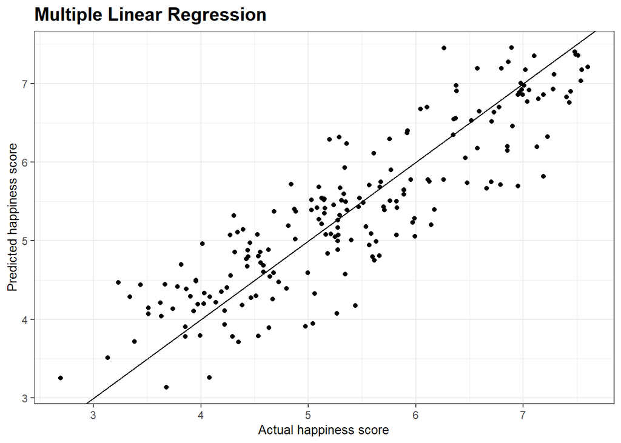

```r
####### Predicting the Test set results
y_pred_lm = predict(ML_regression, newdata = test_set)
Pred_Actual_lm <- as.data.frame(cbind(Prediction = y_pred_lm, Actual = test_set$`hap_score`))
gg.lm <- ggplot(Pred_Actual_lm, aes(Actual, Prediction )) +
  geom_point() + theme_bw() + geom_abline() +
  labs(title = "Multiple Linear Regression", x = "Actual happiness score",
       y = "Predicted happiness score") +
  theme(plot.title = element_text(family = "Helvetica", face = "bold", size = (15)),
        axis.title = element_text(family = "Helvetica", size = (10)))
gg.lm
```

### Support Vector Regression

```r
# Fitting SVR to the dataset
library(e1071)
regressor_svr = svm(formula = `hap_score` ~ .,
                data = training_set,
                type = 'eps-regression',
                kernel = 'radial')
```

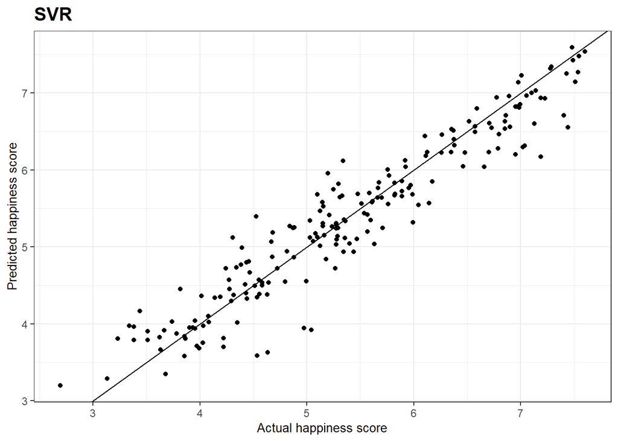

```r
# Predicting a new result
y_pred_svr = predict(regressor_svr,  newdata = test_set)
Pred_Actual_svr <- as.data.frame(cbind(Prediction = y_pred_svr, Actual = test_set$`hap_score`))
Pred_Actual_lm.versus.svr <- cbind(Prediction.lm = y_pred_lm, Prediction.svr = y_pred_svr, Actual = test_set$`hap_score`)
gg.svr <- ggplot(Pred_Actual_svr, aes(Actual, Prediction )) +
  geom_point() + theme_bw() + geom_abline() +
  labs(title = "SVR", x = "Actual happiness score",
       y = "Predicted happiness score") +
  theme(plot.title = element_text(family = "Helvetica", face = "bold", size = (15)),
        axis.title = element_text(family = "Helvetica", size = (10)))
gg.svr
```

### Random Forest

```r
# Fitting Random Forest Regression to the dataset
library(randomForest)
set.seed(2)
regressor_rf = randomForest(x = training_set[-1],
                         y = training_set$`hap_score`,
                         ntree = 500)
```

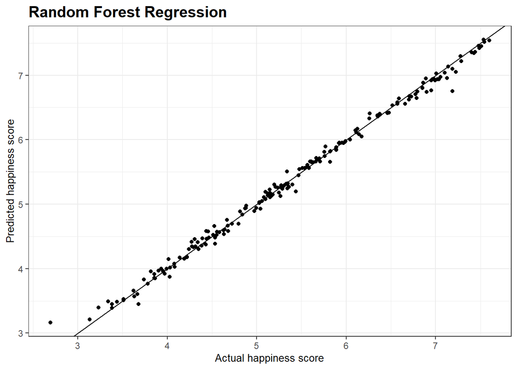

```r
# Predicting a new result with Random Forest Regression
y_pred_rf = predict(regressor_rf, newdata = test_set)
Pred_Actual_rf <- as.data.frame(cbind(Prediction = y_pred_rf, Actual = test_set$`hap_score`))
gg.rf <- ggplot(Pred_Actual_rf, aes(Actual, Prediction )) +
  geom_point() + theme_bw() + geom_abline() +
  labs(title = "Random Forest Regression", x = "Actual happiness score",
       y = "Predicted happiness score") +
  theme(plot.title = element_text(family = "Helvetica", face = "bold", size = (15)),
        axis.title = element_text(family = "Helvetica", size = (10)))
gg.rf
```

### Neural Network

```r
# Fitting Neural Net to the training set
library(neuralnet)
nn <- neuralnet(formula = hap_score ~ co2 + gov_consumption + school_enrollment + unemployment_total + gross_gdp + gross_savings + gov_spending_education + life_exp + GDPPC_2017 + Foreign_Investment + GDPPC_growth + trade_gdp + inflation + net_migration + legal_rights_strength + pop_growth, data=training_set,hidden=10,linear.output=TRUE)
```

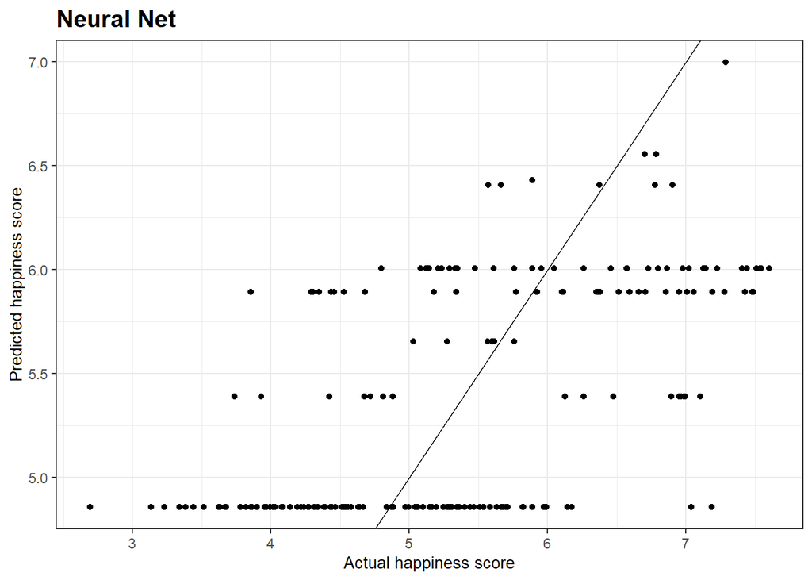

```r
predicted.nn.values <- compute(nn,test_set[,1:16])
Pred_Actual_nn <- as.data.frame(cbind(Prediction = predicted.nn.values$net.result, Actual = test_set$hap_score))
gg.nn <- ggplot(Pred_Actual_nn, aes(Actual, V1 )) +
  geom_point() + theme_bw() + geom_abline() +
  labs(title = "Neural Net", x = "Actual happiness score",
       y = "Predicted happiness score") +
  theme(plot.title = element_text(family = "Helvetica", face = "bold", size = (15)),
      axis.title = element_text(family = "Helvetica", size = (10)))
gg.nn
```